# Reproducible Research - Peer Assessment 2: Analyse of the storm impact on health and economy

## Synopsis

The purpose of the analyse is to explore the U.S. National Oceanic and Atmospheric Administration’s (NOAA) storm database and address the following questions:  
1) Across the United States, which types of events (as indicated in the EVTYPE variable) are most harmful with respect to population health?  
2) Across the United States, which types of events have the greatest economic consequences?

## Settings

```r
library("knitr")
#set general options
opts_chunk$set(echo=TRUE, message = FALSE, warning = FALSE, fig.height=10, fig.width=12, fig.path='figure/', cache.path='cache/')
```

```r
require("R.utils")
require("plyr")
require("lubridate")
require("reshape2")
require("ggplot2")
```

```r
##functions
trim <- function (x) gsub("^\\s+|\\s+$", "", x)
```

## Data Processing

### Getting and Loading Data

From cousera reproductible research course, get the storm data file in a bzip archive format and extract it.

```r
urlfile <- "http://d396qusza40orc.cloudfront.net/repdata%2Fdata%2FStormData.csv.bz2"
zipfile <- "repdata-data-StormData.csv.bz2"
csvfile <- "repdata-data-StormData.csv"

if (!file.exists(zipfile))
  download.file(urlfile, destfile=zipfile)

if (!file.exists(zipfile))
  bunzip2("repdata-data-StormData.csv.bz2", overwrite=T, remove=F)
```

The csv file is very large (over 500 MB), few rows are read and a vector off classes is created then the entire csv with colClasses param is read.

```r
##open large file
small = read.csv(file = csvfile, header = TRUE, nrow=5, stringsAsFactors=FALSE);
classes = sapply(small,class)

##got problem with the vector off classes and replace numeric, logic column by character column
classes["BGN_TIME"]<- "character"
classes["F"]<- "character"
classes[classes == "logical"] = "character"

data = read.csv(file = csvfile, header = TRUE, na.strings = "", colClasses = classes, stringsAsFactors=FALSE);
```

### First analyse

```r
##number of observations
data_dim <- dim(data)
data_dim
```

```
## [1] 902297     37
```

```r
num_rows <- data_dim[1]
num_cols <- data_dim[2]

##column names
colnames(data)
```

```
##  [1] "STATE__"    "BGN_DATE"   "BGN_TIME"   "TIME_ZONE"  "COUNTY"
##  [6] "COUNTYNAME" "STATE"      "EVTYPE"     "BGN_RANGE"  "BGN_AZI"
## [11] "BGN_LOCATI" "END_DATE"   "END_TIME"   "COUNTY_END" "COUNTYENDN"
## [16] "END_RANGE"  "END_AZI"    "END_LOCATI" "LENGTH"     "WIDTH"
## [21] "F"          "MAG"        "FATALITIES" "INJURIES"   "PROPDMG"
## [26] "PROPDMGEXP" "CROPDMG"    "CROPDMGEXP" "WFO"        "STATEOFFIC"
## [31] "ZONENAMES"  "LATITUDE"   "LONGITUDE"  "LATITUDE_E" "LONGITUDE_"
## [36] "REMARKS"    "REFNUM"
```

There are `902 297` observations and `37` columns.

### Cleaning data

for the purposes of the analysis, We keep only related columns: `BGN_DATE, EVTYPE, FATALITIES, INJURIES, PROPDMG, PROPDMGEXP, CROPDMG, CROPDMGEXP`

```r
##eliminate rows with no event
data <- subset(data, FATALITIES > 0 | INJURIES > 0 | PROPDMG > 0 | CROPDMG > 0)

##keep usefull columns
data <- data[,c("BGN_DATE","EVTYPE","FATALITIES","INJURIES","PROPDMG","PROPDMGEXP","CROPDMG","CROPDMGEXP")]

##extract year
data$YEAR <- year(mdy_hms(data$BGN_DATE, truncated = 3))
```

After cleaning observation with no events and keeping only interresting columns, we extract year from the `BGN_DATE` column and estimate the number of events by year.

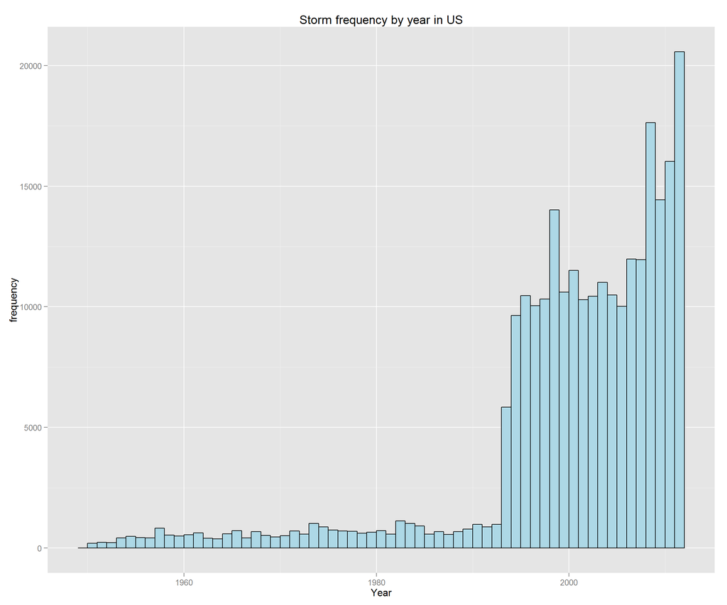

```r
##histogram of the storm frequency by year in US
histo <- ggplot(data, aes(x= YEAR)) +
  geom_histogram(fill="lightblue", colour="black", binwidth=1) +
  xlab("Year") + ylab("frequency") +
  ggtitle("Storm frequency by year in US")
histo
```

```r
##aggregate data and keep the min year where number of events greater or equal to 10000
c<-ddply(data, .(YEAR), summarise, count = length(YEAR) )
min_year <- min(c[c$count >= 10000,])
min_year
```

```
## [1] 1995
```

```r
##filter
data <-subset(data, YEAR >= min_year)

##number of observations
data_dim <- dim(data)
data_dim
```

```
## [1] 211775      9
```

Based on the above histogram, the number of events significatly change (10 000 observations) arround `1995`. We decided to subset and get `211 775` observations.

According to the Storm Data Event Table, principals events type are harmonized.

```r
##cleanig events type
data$EVTYPE <- toupper(tolower(data$EVTYPE))
data$EVTYPE <- gsub("  "," ", x = data$EVTYPE)
data$EVTYPE <- trim(data$EVTYPE)
data$EVTYPE[grep("HURRICANE*", data$EVTYPE)] = "HURRICANE (TYPHOON)"
data$EVTYPE[grep("FLASH FLOOD*", data$EVTYPE)] = "FLASH FLOOD"
data$EVTYPE[grep("FLOOD/FLASH*", data$EVTYPE)] = "FLASH FLOOD"
data$EVTYPE[grep("WATERSPOUT*", data$EVTYPE)] = "WATERSPOUT"
data$EVTYPE[grep("TORNADO*", data$EVTYPE)] = "TORNADO"
data$EVTYPE[grep("WINTER STORM*", data$EVTYPE)] = "WINTER STORM"
data$EVTYPE[grep("TROPICAL STORM*", data$EVTYPE)] = "TROPICAL STORM"
data$EVTYPE[grep("HEAVY RAIN*", data$EVTYPE)] = "HEAVY RAIN"
data$EVTYPE[grep("HEAVY SNOW*", data$EVTYPE)] = "HEAVY SNOW"
data$EVTYPE[grep("TSTM WIND*", data$EVTYPE)] = "THUNDERSTORM WIND"
data$EVTYPE[grep("THUNDERSTORM WIND*", data$EVTYPE)] = "THUNDERSTORM WIND"
data$EVTYPE[grep("THUNDERSTORM[A-Z]+ WIND*", data$EVTYPE)] = "THUNDERSTORM WIND"
data$EVTYPE[grep("^HAIL", data$EVTYPE)] = "HAIL"
data$EVTYPE[grepl("HAIL", data$EVTYPE) & data$EVTYPE != "MARINE HAIL"]  = "HAIL"
```

## Results

### Compute property damage coefficient and crop damage coefficient

```r
##estimate coef for damage
coef_propdmg <- data.frame(PROPDMGEXP=c("H","K","M","B","+","-","?",as.character(0:8)),
                           coef_prop=c(100,1000,10^6,10^9,1,0,0,rep(1,9))
)
coef_cropdmg <- data.frame(CROPDMGEXP=c("H","K","M","B","+","-","?",as.character(0:8)),
                           coef_crop=c(100,1000,10^6,10^9,1,0,0,rep(1,9))
)
##merge coef with data
data<- merge(x = data, y = coef_propdmg, by = "PROPDMGEXP", all.x = TRUE)
data<- merge(x = data, y = coef_cropdmg, by = "CROPDMGEXP", all.x = TRUE)
```

### Question 1 : Across the United States, which types of events are most harmful with respect to population health?

Aggregate fatalities and injuries and show the top 10.

```r
## Aggregate fatalities and injuries and show the top 10
d <- ddply(data, .(EVTYPE), summarise,
                      FATALITIES = sum(FATALITIES, na.rm = TRUE),
                      INJURIES = sum(INJURIES, na.rm = TRUE),
                      TOTAL = INJURIES + FATALITIES)

d<-d[order(-d$TOTAL),]
t<- head(d, n = 10)
t
```

```
##                  EVTYPE FATALITIES INJURIES TOTAL
## 184             TORNADO       1545    21783 23328
## 38       EXCESSIVE HEAT       1903     6525  8428
## 50                FLOOD        423     6769  7192
## 179   THUNDERSTORM WIND        437     5649  6086
## 122           LIGHTNING        729     4631  5360
## 76                 HEAT        924     2030  2954
## 49          FLASH FLOOD        951     1739  2690
## 215        WINTER STORM        196     1313  1509
## 98  HURRICANE (TYPHOON)        135     1327  1462
## 94            HIGH WIND        241     1093  1334
```

Melt the dataset and produce an histogram of the 10 most harmful types of events.

[figure not shown]

```r
m<- melt(t)

brks <- pretty(range(m$value), n = nclass.FD(m$value), min.n = 1)
bwidth <- brks[2]-brks[1]

harm <- ggplot(data = m,aes(x=EVTYPE, y=value, fill=factor(variable)), color=factor(variable)) +
  stat_summary(fun.y = sum, position = position_dodge(), geom = "bar", binwidth=bwidth) +
  theme(axis.text.x = element_text(angle = 45,hjust = 1)) +
  ylab("Number of injuries / fatalities") + xlab("Event type")+
  guides(fill=guide_legend(title=NULL))+
  ggtitle("Total injuries and fatalities by Storm event in US between 1995 and 2011")
harm
```

Based on the above histogram, Tornado causes the most injuries. Excessive Heat cause the most fatalities but Tornado fatalities is very close. We find that, injuries are most important than fatalities.

### Question 2:Across the United States, which types of events have the greatest economic consequences?

Aggregate property damage and crop damage and show the top 10.

```r
d <- ddply(data, .(EVTYPE), summarise,
           PROPERTY_DAMAGE = sum(PROPDMG * coef_prop, na.rm = TRUE),
           CROP_DAMAGE = sum(CROPDMG * coef_crop, na.rm = TRUE),
           TOTAL = CROP_DAMAGE + PROPERTY_DAMAGE)

d<-d[order(-d$TOTAL),]
t<- head(d, n = 10)
t
```

```
##                  EVTYPE PROPERTY_DAMAGE CROP_DAMAGE        TOTAL
## 50                FLOOD    144022037050  5422810400 149444847450
## 98  HURRICANE (TYPHOON)     84630180010  5504792800  90134972810
## 170         STORM SURGE     43193536000        5000  43193541000
## 184             TORNADO     24919990847   296602970  25216593817
## 73                 HAIL     15282614081  2634660070  17917274151
## 49          FLASH FLOOD     15535161010  1448959000  16984120010
## 30              DROUGHT      1046106000 13922066000  14968172000
## 179   THUNDERSTORM WIND      8655878991  1122363500   9778242491
## 187      TROPICAL STORM      7658335550   693886000   8352221550
## 94            HIGH WIND      5259785360   633561300   5893346660
```

Melt the dataset and produce an histogram of the 10 types of events which have the greatest economic consequences

[figure not shown]

```r
m<- melt(t)

brks <- pretty(range(m$value), n = nclass.FD(m$value), min.n = 1)
bwidth <- brks[2]-brks[1]

eco <- ggplot(data = m,aes(x=EVTYPE, y=value, fill=factor(variable)), color=factor(variable)) +
  stat_summary(fun.y = sum, position = position_dodge(), geom = "bar", binwidth=bwidth) +
  theme(axis.text.x = element_text(angle = 45,hjust = 1)) +
  ylab("Economic damage") + xlab("Event type")+
  guides(fill=guide_legend(title=NULL)) +
  ggtitle("Total property and crop damage by Storm event in US between 1995 and 2011")
eco
```

Based on the above histogram, flood cause most property damage. Drought cause most crop damage. We find that, property damage are more important than crop damage.